# Data Analysis for Ford Gobike System Data by Caleb Denzeil

### Introduction

The ford Gobike dataset includes information about individual rides made in a bike sharing system covering the greater San Francisco Bay area. The dataset has 16 columns and 183412 rows. The columns are:

- duration_sec - duration time in seconds
- start_time - starting time
- end_time - ending time
- start_station_id - Starting station id
- start_station_name - The name of the starting station
- start_station_latitude - Starting station in latitude
- start_station_longitude - Starting station location in longitude
- end_station_id - Ending station id
- end_station_name - Ending station name
- end_station_latitude -Ending station location in latitude
- end_station_longitude - Ending station location in longitude
- bike_id - bike id
- user_type - User type either Subscriber or Customer
- member_birth_year - Member birth year
- member_gender - Member gender
- bike_share_for_all_trip - is the bike used for round trips?

## Preliminary wrangling

### Gather

```python
#import the necessary libraries
import pandas as pd
import numpy as np
import matplotlib.pyplot as plt
%matplotlib inline
import seaborn as sns
```

```python
#grid style
sns.set_style('darkgrid')
```

```python
#import the data
bike=pd.read_csv('201902-fordgobike-tripdata.csv')
bike
```

|  | duration_sec | start_time | end_time | start_station_id | start_station_name | start_station_latitude | start_station_longitude | end_station_id | end_station_name | end_station_latitude | end_station_longitude | bike_id | user_type | member_birth_year | member_gender | bike_share_for_all_trip |
| --- | --- | --- | --- | --- | --- | --- | --- | --- | --- | --- | --- | --- | --- | --- | --- | --- |
| 0 | 52185 | 2019-02-28 17:32:10.1450 | 2019-03-01 08:01:55.9750 | 21.0 | Montgomery St BART Station (Market St at 2nd St) | 37.789625 | -122.400811 | 13.0 | Commercial St at Montgomery St | 37.794231 | -122.402923 | 4902 | Customer | 1984.0 | Male | No |
| 1 | 42521 | 2019-02-28 18:53:21.7890 | 2019-03-01 06:42:03.0560 | 23.0 | The Embarcadero at Steuart St | 37.791464 | -122.391034 | 81.0 | Berry St at 4th St | 37.775880 | -122.393170 | 2535 | Customer | NaN | NaN | No |
| 2 | 61854 | 2019-02-28 12:13:13.2180 | 2019-03-01 05:24:08.1460 | 86.0 | Market St at Dolores St | 37.769305 | -122.426826 | 3.0 | Powell St BART Station (Market St at 4th St) | 37.786375 | -122.404904 | 5905 | Customer | 1972.0 | Male | No |
| 3 | 36490 | 2019-02-28 17:54:26.0100 | 2019-03-01 04:02:36.8420 | 375.0 | Grove St at Masonic Ave | 37.774836 | -122.446546 | 70.0 | Central Ave at Fell St | 37.773311 | -122.444293 | 6638 | Subscriber | 1989.0 | Other | No |
| 4 | 1585 | 2019-02-28 23:54:18.5490 | 2019-03-01 00:20:44.0740 | 7.0 | Frank H Ogawa Plaza | 37.804562 | -122.271738 | 222.0 | 10th Ave at E 15th St | 37.792714 | -122.248780 | 4898 | Subscriber | 1974.0 | Male | Yes |
| ... | ... | ... | ... | ... | ... | ... | ... | ... | ... | ... | ... | ... | ... | ... | ... | ... |
| 183407 | 480 | 2019-02-01 00:04:49.7240 | 2019-02-01 00:12:50.0340 | 27.0 | Beale St at Harrison St | 37.788059 | -122.391865 | 324.0 | Union Square (Powell St at Post St) | 37.788300 | -122.408531 | 4832 | Subscriber | 1996.0 | Male | No |
| 183408 | 313 | 2019-02-01 00:05:34.7440 | 2019-02-01 00:10:48.5020 | 21.0 | Montgomery St BART Station (Market St at 2nd St) | 37.789625 | -122.400811 | 66.0 | 3rd St at Townsend St | 37.778742 | -122.392741 | 4960 | Subscriber | 1984.0 | Male | No |
| 183409 | 141 | 2019-02-01 00:06:05.5490 | 2019-02-01 00:08:27.2200 | 278.0 | The Alameda at Bush St | 37.331932 | -121.904888 | 277.0 | Morrison Ave at Julian St | 37.333658 | -121.908586 | 3824 | Subscriber | 1990.0 | Male | Yes |
| 183410 | 139 | 2019-02-01 00:05:34.3600 | 2019-02-01 00:07:54.2870 | 220.0 | San Pablo Ave at MLK Jr Way | 37.811351 | -122.273422 | 216.0 | San Pablo Ave at 27th St | 37.817827 | -122.275698 | 5095 | Subscriber | 1988.0 | Male | No |
| 183411 | 271 | 2019-02-01 00:00:20.6360 | 2019-02-01 00:04:52.0580 | 24.0 | Spear St at Folsom St | 37.789677 | -122.390428 | 37.0 | 2nd St at Folsom St | 37.785000 | -122.395936 | 1057 | Subscriber | 1989.0 | Male | No |

183412 rows × 16 columns

```python
#make a copy of the original dataframe
copy_b=bike.copy()
```

### Assess

In this section I will assess the data to locate tidiness and quality issues using visual and programmatic assessment

```python
copy_b.info()
```

```
<class 'pandas.core.frame.DataFrame'>
RangeIndex: 183412 entries, 0 to 183411
Data columns (total 16 columns):
 #   Column                   Non-Null Count   Dtype
---  ------                   --------------   -----
 0   duration_sec             183412 non-null  int64
 1   start_time               183412 non-null  object
 2   end_time                 183412 non-null  object
 3   start_station_id         183215 non-null  float64
 4   start_station_name       183215 non-null  object
 5   start_station_latitude   183412 non-null  float64
 6   start_station_longitude  183412 non-null  float64
 7   end_station_id           183215 non-null  float64
 8   end_station_name         183215 non-null  object
 9   end_station_latitude     183412 non-null  float64
 10  end_station_longitude    183412 non-null  float64
 11  bike_id                  183412 non-null  int64
 12  user_type                183412 non-null  object
 13  member_birth_year        175147 non-null  float64
 14  member_gender            175147 non-null  object
 15  bike_share_for_all_trip  183412 non-null  object
dtypes: float64(7), int64(2), object(7)
memory usage: 22.4+ MB
```

```python
copy_b.head()
```

|  | duration_sec | start_time | end_time | start_station_id | start_station_name | start_station_latitude | start_station_longitude | end_station_id | end_station_name | end_station_latitude | end_station_longitude | bike_id | user_type | member_birth_year | member_gender | bike_share_for_all_trip |
| --- | --- | --- | --- | --- | --- | --- | --- | --- | --- | --- | --- | --- | --- | --- | --- | --- |
| 0 | 52185 | 2019-02-28 17:32:10.1450 | 2019-03-01 08:01:55.9750 | 21.0 | Montgomery St BART Station (Market St at 2nd St) | 37.789625 | -122.400811 | 13.0 | Commercial St at Montgomery St | 37.794231 | -122.402923 | 4902 | Customer | 1984.0 | Male | No |
| 1 | 42521 | 2019-02-28 18:53:21.7890 | 2019-03-01 06:42:03.0560 | 23.0 | The Embarcadero at Steuart St | 37.791464 | -122.391034 | 81.0 | Berry St at 4th St | 37.775880 | -122.393170 | 2535 | Customer | NaN | NaN | No |
| 2 | 61854 | 2019-02-28 12:13:13.2180 | 2019-03-01 05:24:08.1460 | 86.0 | Market St at Dolores St | 37.769305 | -122.426826 | 3.0 | Powell St BART Station (Market St at 4th St) | 37.786375 | -122.404904 | 5905 | Customer | 1972.0 | Male | No |
| 3 | 36490 | 2019-02-28 17:54:26.0100 | 2019-03-01 04:02:36.8420 | 375.0 | Grove St at Masonic Ave | 37.774836 | -122.446546 | 70.0 | Central Ave at Fell St | 37.773311 | -122.444293 | 6638 | Subscriber | 1989.0 | Other | No |
| 4 | 1585 | 2019-02-28 23:54:18.5490 | 2019-03-01 00:20:44.0740 | 7.0 | Frank H Ogawa Plaza | 37.804562 | -122.271738 | 222.0 | 10th Ave at E 15th St | 37.792714 | -122.248780 | 4898 | Subscriber | 1974.0 | Male | Yes |

```python
copy_b.isnull().sum()
```

```
duration_sec                  0
start_time                    0
end_time                      0
start_station_id            197
start_station_name          197
start_station_latitude        0
start_station_longitude       0
end_station_id              197
end_station_name            197
end_station_latitude          0
end_station_longitude         0
bike_id                       0
user_type                     0
member_birth_year          8265
member_gender              8265
bike_share_for_all_trip       0
dtype: int64
```

```python
#find duplicated values
copy_b.duplicated().sum()
```

```
0
```

```python
#describe the data
copy_b.describe()
```

|  | duration_sec | start_station_id | start_station_latitude | start_station_longitude | end_station_id | end_station_latitude | end_station_longitude | bike_id | member_birth_year |
| --- | --- | --- | --- | --- | --- | --- | --- | --- | --- |
| count | 183412.000000 | 183215.000000 | 183412.000000 | 183412.000000 | 183215.000000 | 183412.000000 | 183412.000000 | 183412.000000 | 175147.000000 |
| mean | 726.078435 | 138.590427 | 37.771223 | -122.352664 | 136.249123 | 37.771427 | -122.352250 | 4472.906375 | 1984.806437 |
| std | 1794.389780 | 111.778864 | 0.099581 | 0.117097 | 111.515131 | 0.099490 | 0.116673 | 1664.383394 | 10.116689 |
| min | 61.000000 | 3.000000 | 37.317298 | -122.453704 | 3.000000 | 37.317298 | -122.453704 | 11.000000 | 1878.000000 |
| 25% | 325.000000 | 47.000000 | 37.770083 | -122.412408 | 44.000000 | 37.770407 | -122.411726 | 3777.000000 | 1980.000000 |
| 50% | 514.000000 | 104.000000 | 37.780760 | -122.398285 | 100.000000 | 37.781010 | -122.398279 | 4958.000000 | 1987.000000 |
| 75% | 796.000000 | 239.000000 | 37.797280 | -122.286533 | 235.000000 | 37.797320 | -122.288045 | 5502.000000 | 1992.000000 |
| max | 85444.000000 | 398.000000 | 37.880222 | -121.874119 | 398.000000 | 37.880222 | -121.874119 | 6645.000000 | 2001.000000 |

### Quality issues

- Start_time and end_time columns are in object format
- start_station_id,start_station_name,end_station_id,end_station_name, member_birth_year and member_gender have missing values.

## Cleaning

- In this section, I will address the quality issues

```python
# Change the start and end_time columns from object to dateformat
def date_conversion(start,end):
    global copy_b
    copy_b[start]=pd.to_datetime(copy_b[start])
    copy_b[end]=pd.to_datetime(copy_b[end])

    #create new columns for starting and ending time
    copy_b['Starting_time']=copy_b[start].dt.strftime('Y%-m%-d%')
    copy_b['Ending_time']=copy_b[end].dt.strftime('Y%-m%-d%')

    #separate the hours
    copy_b['Start_hour']=copy_b[start].dt.hour
    copy_b['End_hour']=copy_b[end].dt.hour

    #separate the days
    copy_b['Start_day']=copy_b[start].dt.strftime('%a')
    copy_b['End_day']=copy_b[end].dt.strftime('%a')

    #separate the months
    copy_b['Start_month']=copy_b[start].dt.strftime('%B')
    copy_b['End_month']=copy_b[end].dt.strftime('%B')

    copy_b=copy_b.drop(columns=[start,end])
```

```python
#call the function date_conversion
date_conversion('start_time','end_time')
```

```python
#check for the changes
copy_b.head()
```

[output not shown]

5 rows × 22 columns

```python
# drop rows with missing values
copy_b.dropna(axis=0)
```

[output not shown]

174952 rows × 22 columns

```python
copy_b.info()
```

```
<class 'pandas.core.frame.DataFrame'>
RangeIndex: 183412 entries, 0 to 183411
Data columns (total 22 columns):
 #   Column                   Non-Null Count   Dtype
---  ------                   --------------   -----
 0   duration_sec             183412 non-null  int64
 1   start_station_id         183215 non-null  float64
 2   start_station_name       183215 non-null  object
 3   start_station_latitude   183412 non-null  float64
 4   start_station_longitude  183412 non-null  float64
 5   end_station_id           183215 non-null  float64
 6   end_station_name         183215 non-null  object
 7   end_station_latitude     183412 non-null  float64
 8   end_station_longitude    183412 non-null  float64
 9   bike_id                  183412 non-null  int64
 10  user_type                183412 non-null  object
 11  member_birth_year        175147 non-null  float64
 12  member_gender            175147 non-null  object
 13  bike_share_for_all_trip  183412 non-null  object
 14  Starting_time            183412 non-null  object
 15  Ending_time              183412 non-null  object
 16  Start_hour               183412 non-null  int64
 17  End_hour                 183412 non-null  int64
 18  Start_day                183412 non-null  object
 19  End_day                  183412 non-null  object
 20  Start_month              183412 non-null  object
 21  End_month                183412 non-null  object
dtypes: float64(7), int64(4), object(11)
memory usage: 30.8+ MB
```

## What are the main features in your dataset?

- The main features in my dataset are `duration_sec`,`Starting_time` and `User_type`

## What features in the dataset do you think will help support your investigation into your feature(s) of interest?

- From the dataset, some of the features that will assist me in my investigation are the start, end stations,user_type and the subdivided columns for starting and ending time.

# Univariate Exploration

### Q1. Which gender rides more bikes?

```python
copy_b.member_gender.value_counts()
```

```
Male      130651
Female     40844
Other       3652
Name: member_gender, dtype: int64
```

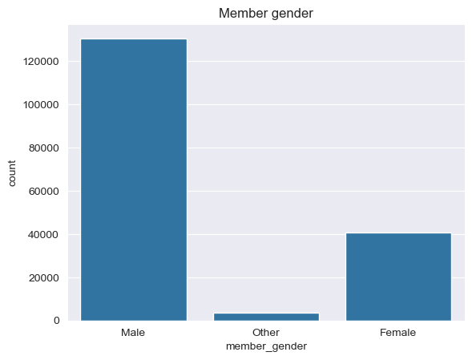

```python
#plot a countplot for gender
color=sns.color_palette()[0]
sns.countplot(data=copy_b,x='member_gender',color=color)
plt.title('Member gender');
```

### From the bar chart, Males have taken more rides than females and other.

### Q2. How many user types are there?

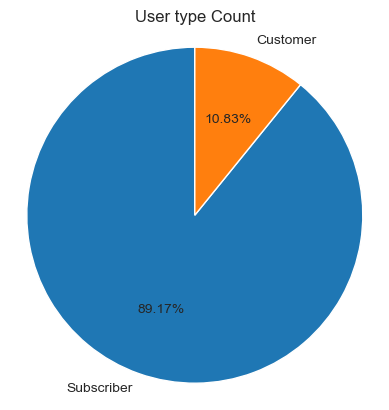

```python
#plot a pie chart
sorted_counts=copy_b.user_type.value_counts()
plt.pie(sorted_counts,labels=sorted_counts.index,startangle=90,autopct='%1.2f%%')
plt.axis('square')
plt.title('User type Count');
```

### From the analyis above, there is a clear indication that their are more subscribers than customers.

### Q3. What is the distribution for duration?

```python
copy_b.duration_sec.describe()
```

```
count    183412.000000
mean        726.078435
std        1794.389780
min          61.000000
25%         325.000000
50%         514.000000
75%         796.000000
max       85444.000000
Name: duration_sec, dtype: float64
```

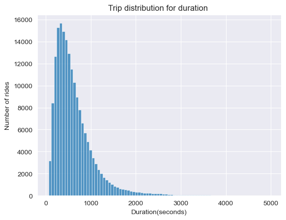

```python
bin_edge=np.arange(61,5000,60)
sns.histplot(data=copy_b,x='duration_sec',bins=bin_edge)
plt.title('Trip distribution for duration ')
plt.xlabel('Duration(seconds)')
plt.ylabel('Number of rides');
```

### The histogram is right skewed and most of the riders range from 300 to 700 seconds

### Q3. Which day has the highest number of riders?

```python
#convert the column Start_day to a categorital type
classes=['Sun','Mon','Tue','Wed','Thu','Fri','Sat']

vclasses=pd.api.types.CategoricalDtype(ordered=True, categories=classes)

copy_b['Start_day']=copy_b['Start_day'].astype(vclasses)
```

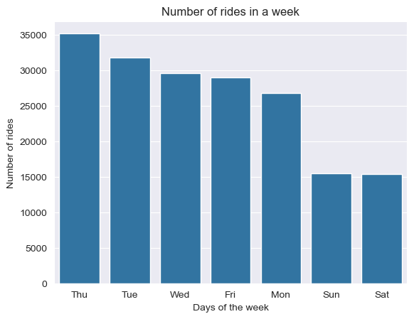

```python
order=copy_b.Start_day.value_counts().index
sns.countplot(data=copy_b,x='Start_day',color=color,order=order)
plt.title('Number of rides in a week')
plt.xlabel('Days of the week')
plt.ylabel('Number of rides');
```

### From the bar chart, Thursday has the highest number of riders and most people ride from Monday to Friday. The weekend has less riders compared to the weekdays(Mon-Fri).

### Q4. At what time of the day do most riders show up?

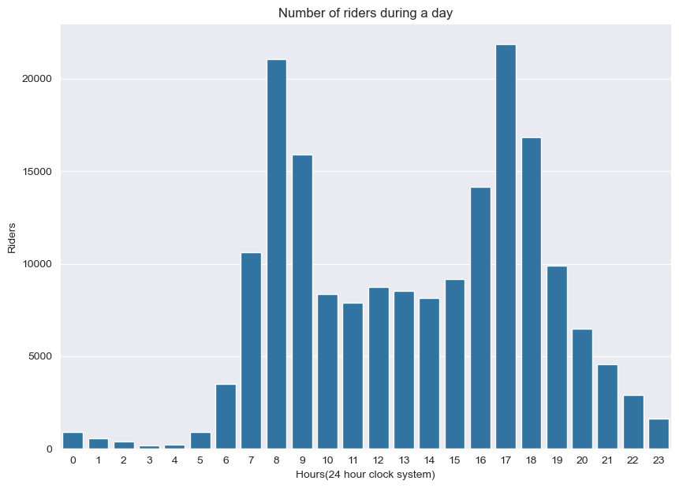

```python
#convert the start month column to a categoricol data type

plt.figure(figsize=(10,7))
sns.countplot(data=copy_b,x='Start_hour',color=color)
plt.title('Number of riders during a day')
plt.xlabel('Hours(24 hour clock system)')
plt.ylabel('Riders');
```

### Their is a clear indication that most people show up between 07:00 in the morning and at 17:00 in the evening.

### Q5. What are the top 10 most used start stations?

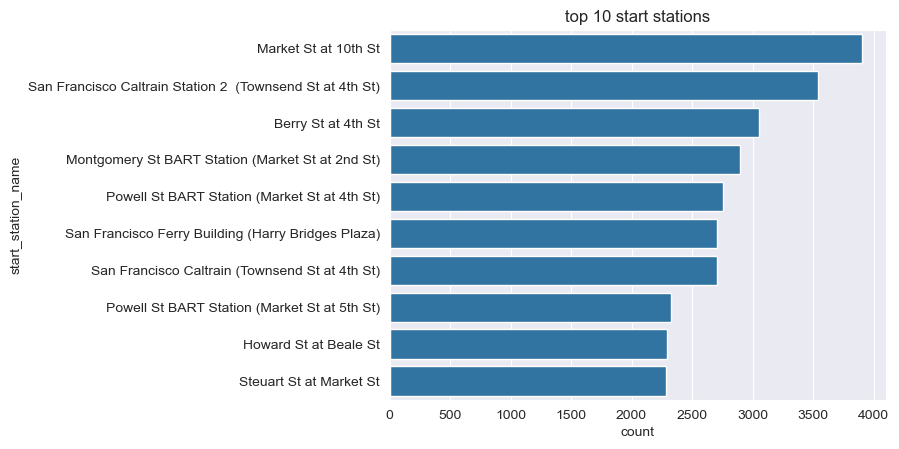

```python
#plot a count plot for the top 10 starting stations
stations=copy_b.start_station_name.value_counts().index[0:10]
sns.countplot(data=copy_b,y='start_station_name',color=color,order=stations)
plt.title('top 10 start stations');
```

### Market St at 10th is the most station as a starting point for most riders

### Q6. What are the top 10 ending stations?

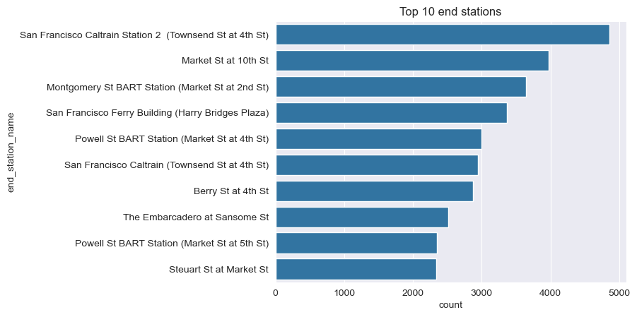

```python
#plot a countplot for the top 10 ending stations
stations=copy_b.end_station_name.value_counts().index[0:10]
sns.countplot(data=copy_b,y='end_station_name',color=color,order=stations)
plt.title('Top 10 end stations');
```

### San Francisco Caltrain Station is the most used ending station.

# Univariate Exploration summary:

- `Duration-sec`:
  - Most of the rides took between 3-12 minutes
- `Start-time`:
  - According to hours: Most riders show up between 8 and 17
  - According to days of the week: Thursday has the highest number of riders and most people ride from Monday to Friday. The weekend has less riders compared to the weekdays(Mon-Fri).
- `User_type`:
  - A majority of the users were subscribers(89.17%)
- I divided the start-time and end-time columns into:
  - Starting_time
  - Ending_time
  - Start_hour
  - End_hour
  - Start_day
  - End_day
  - Start_month
  - End_month

# Bivariate exploration

### 1. What is the comparison between customers and subscribers during the week?

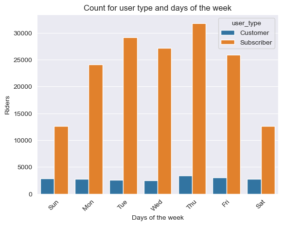

```python
sns.countplot(data=copy_b,x='Start_day',hue='user_type')
plt.xticks(rotation=45)
plt.xlabel('Days of the week')
plt.ylabel('Riders')
plt.title('Count for user type and days of the week');
```

```python
#let's visualize the above bar chart in a different way
group_data=copy_b.groupby('Start_day')['user_type'].value_counts()
group_data
```

```
Start_day  user_type
Sun        Subscriber    12627
           Customer       2896
Mon        Subscriber    24111
           Customer       2741
Tue        Subscriber    29207
           Customer       2606
Wed        Subscriber    27175
           Customer       2466
Thu        Subscriber    31807
           Customer       3390
Fri        Subscriber    25951
           Customer       3030
Sat        Subscriber    12666
           Customer       2739
Name: user_type, dtype: int64
```

```python
#Use series.reset_index() to a series into a dataframe object
group_data=group_data.reset_index(name='count')
group_data
```

|  | Start_day | user_type | count |
| --- | --- | --- | --- |
| 0 | Sun | Subscriber | 12627 |
| 1 | Sun | Customer | 2896 |
| 2 | Mon | Subscriber | 24111 |
| 3 | Mon | Customer | 2741 |
| 4 | Tue | Subscriber | 29207 |
| 5 | Tue | Customer | 2606 |
| 6 | Wed | Subscriber | 27175 |
| 7 | Wed | Customer | 2466 |
| 8 | Thu | Subscriber | 31807 |
| 9 | Thu | Customer | 3390 |
| 10 | Fri | Subscriber | 25951 |
| 11 | Fri | Customer | 3030 |
| 12 | Sat | Subscriber | 12666 |
| 13 | Sat | Customer | 2739 |

```python
#divide the count column with 100 to make it smaller
group_data['count']=group_data['count']/100
```

```python
group_data
```

|  | Start_day | user_type | count |
| --- | --- | --- | --- |
| 0 | Sun | Subscriber | 126.27 |
| 1 | Sun | Customer | 28.96 |
| 2 | Mon | Subscriber | 241.11 |
| 3 | Mon | Customer | 27.41 |
| 4 | Tue | Subscriber | 292.07 |
| 5 | Tue | Customer | 26.06 |
| 6 | Wed | Subscriber | 271.75 |
| 7 | Wed | Customer | 24.66 |
| 8 | Thu | Subscriber | 318.07 |
| 9 | Thu | Customer | 33.90 |
| 10 | Fri | Subscriber | 259.51 |
| 11 | Fri | Customer | 30.30 |
| 12 | Sat | Subscriber | 126.66 |
| 13 | Sat | Customer | 27.39 |

```python
# Use DataFrame.pivot() to rearrange the data, to have vehicle class on rows
group_data=group_data.pivot(index='Start_day',columns='user_type',values='count')
group_data
```

| user_type Start_day | Customer | Subscriber |
| --- | --- | --- |
| Sun | 28.96 | 126.27 |
| Mon | 27.41 | 241.11 |
| Tue | 26.06 | 292.07 |
| Wed | 24.66 | 271.75 |
| Thu | 33.90 | 318.07 |
| Fri | 30.30 | 259.51 |
| Sat | 27.39 | 126.66 |

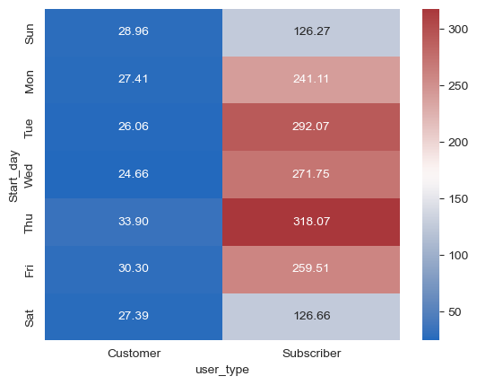

```python
#plot the heatmap
sns.heatmap(group_data,annot=True,fmt='.2f',cmap='vlag');
```

### Q2. At what times do customers and subscribers show up?

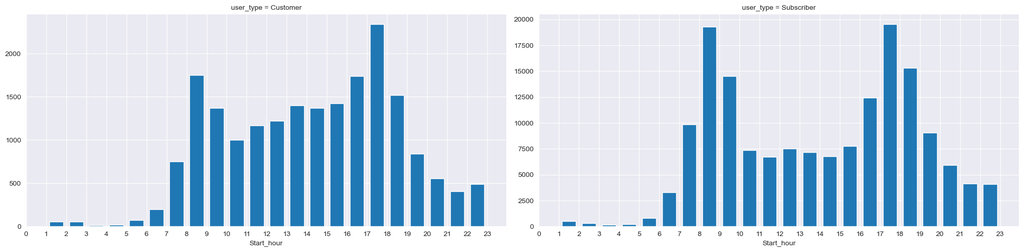

```python
# facetting histograms of start_hour against user_type
bin_edges = np.arange(1, 23+1, 1)
g = sns.FacetGrid(data = copy_b, col = 'user_type', height=5, aspect=2, sharey=False)
g.map(plt.hist, 'Start_hour',bins=bin_edges, rwidth = 0.7)
plt.xticks(np.arange(0, 23+1, 1));
```

### From the graph most customers ride between 17 and 18 while subscribers either 8 or 17

### Q3 What is the relationship between gender and hours of the day?

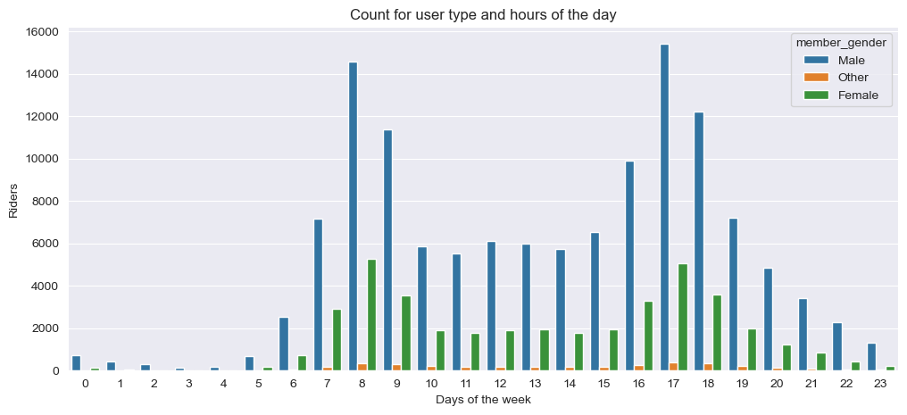

```python
plt.figure(figsize=(12,5))
sns.countplot(data=copy_b,x='Start_hour',hue='member_gender')
plt.xlabel('Days of the week')
plt.ylabel('Riders')
plt.title('Count for user type and hours of the day');
```

### From the bar chart, their are more than females, and both males and females show up in high numbers betweeen 8 and 17.

### Q4. What is the distribution for user type according to duration?

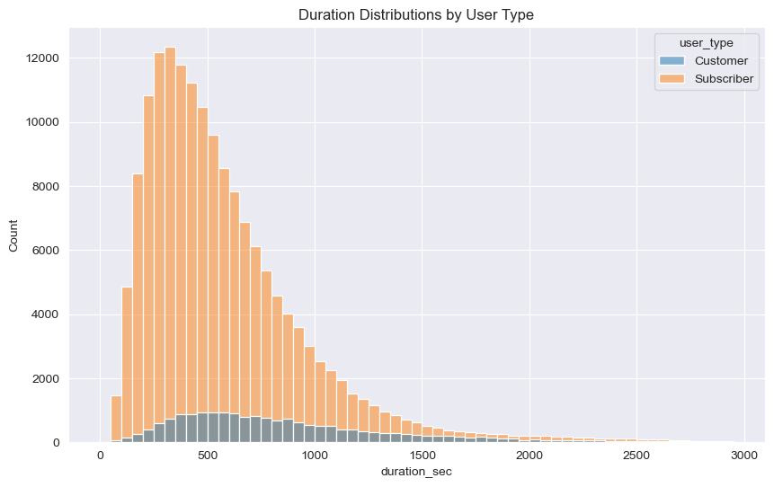

```python
#plot a histogram for duration
plt.figure(figsize=(10,6))
bins = np.arange(0, 3000, 50)
sns.histplot(data=copy_b, x='duration_sec', hue="user_type", bins=bins)
plt.title('Duration Distributions by User Type')
plt.show();
```

### Q5. What is the average duration for riders during the week?

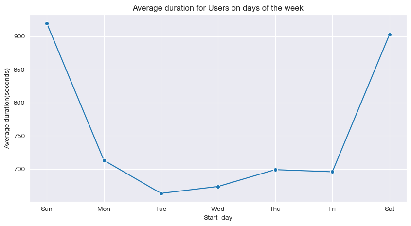

```python
average_duration = copy_b.groupby('Start_day').duration_sec.mean()

# plot a line plot
plt.figure(figsize=[10,5])
sns.lineplot(x=average_duration.index, y=average_duration.values, marker='o')
plt.xticks(np.arange(0,7))
plt.ylabel('Average duration(seconds)')
plt.title('Average duration for Users on days of the week');
```

### The average duration is high on the weekends compared to (Mon-Fri).

# Multivariate Exploration

### Q1. What is the average duration for the week for each user

```python
combined_duration = copy_b.groupby(['Start_day','user_type']).duration_sec.mean()
combined_duration=combined_duration.reset_index()
combined_duration
```

|  | Start_day | user_type | duration_sec |
| --- | --- | --- | --- |
| 0 | Sun | Customer | 1858.298343 |
| 1 | Sun | Subscriber | 704.489269 |
| 2 | Mon | Customer | 1440.821598 |
| 3 | Mon | Subscriber | 630.437145 |
| 4 | Tue | Customer | 1129.448196 |
| 5 | Tue | Subscriber | 621.713904 |
| 6 | Wed | Customer | 1242.210057 |
| 7 | Wed | Subscriber | 622.079006 |
| 8 | Thu | Customer | 1334.841003 |
| 9 | Thu | Subscriber | 631.277235 |
| 10 | Fri | Customer | 1199.634323 |
| 11 | Fri | Subscriber | 636.967554 |
| 12 | Sat | Customer | 1811.849580 |
| 13 | Sat | Subscriber | 706.051792 |

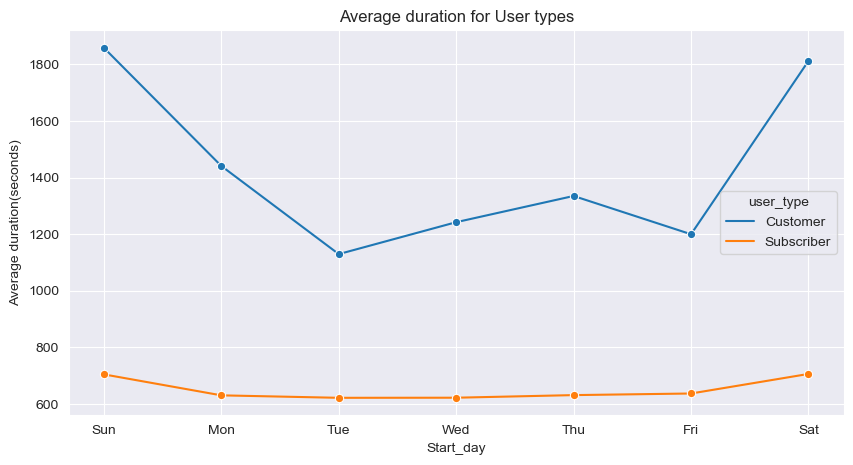

```python
# plot a line plot
plt.figure(figsize=[10,5])
sns.lineplot(x=combined_duration['Start_day'], y=combined_duration['duration_sec'],hue=combined_duration['user_type'], marker='o')
plt.xticks(np.arange(0,7))
plt.ylabel('Average duration(seconds)')
plt.title('Average duration for User types');
```

### Well,it is clear that customers lasted longer than subscribers on average

### Q2. What is the relationship between gender,user type and day of the week

```python
g = copy_b.groupby(['Start_day', 'member_gender', 'user_type']).size().reset_index(name='count')
g = g.pivot(index='Start_day', columns=['member_gender', 'user_type'], values = 'count').dropna()
g
```

| member_gender user_type Start_day | Female Customer | Female Subscriber | Male Customer | Male Subscriber | Other Customer | Other Subscriber |
| --- | --- | --- | --- | --- | --- | --- |
| Sun | 704 | 2868 | 1536 | 9095 | 64 | 265 |
| Mon | 682 | 5128 | 1591 | 17750 | 51 | 484 |
| Tue | 617 | 6646 | 1616 | 21172 | 50 | 515 |
| Wed | 552 | 6013 | 1493 | 19795 | 72 | 531 |
| Thu | 787 | 7255 | 1998 | 22965 | 90 | 638 |
| Fri | 661 | 5475 | 1808 | 19158 | 76 | 504 |
| Sat | 644 | 2812 | 1487 | 9187 | 52 | 260 |

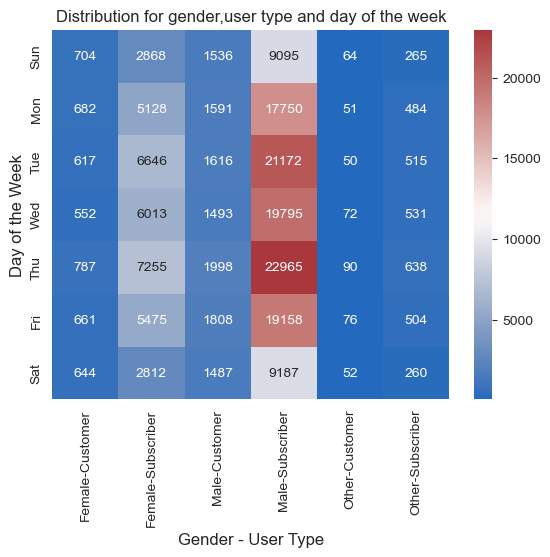

```python
sns.heatmap(g, annot=True, fmt='.0f', cmap='vlag')
plt.xlabel("Gender - User Type", fontsize=12)
plt.ylabel("Day of the Week", fontsize=12)
plt.title('Distribution for gender,user type and day of the week');
```

### The number of riders tend to be high between (Mon-Fri) and most of the riders are male subscribers.

- On average customers lasted than customers
- The number of riders tend to be high between (Mon-Fri) and most of the riders are male subscribers

## Conclusion

```python
#save the cleaned ford file
copy_b.to_csv('2019-cleanedford.csv', index=False)
```